# Data Challenge 5: Clustering Tissue Samples

Ziyan Hu

Due 5:59pm on Nov 17, 2023

Link to the github: https://github.com/freyahu2000/DataChallenge6

### 1.Simulate Data

We will begin by simulating some data to do principal component analysis (PCA) and clustering on. Use the following provided code to simulate data for this exercise. We will be simulating data from two groups.

```r
## load in required libraries
library(hbim)
library(mvtnorm)

## set a seed for reproducibility
set.seed(12345)

## create an exhangeable variance covariance for the data
sigma <- make.v(n = 100, r = 0.6, sig2 = 1)

## create centers for the two clusters.
center_1 <- rep(1, 100)
center_2 <- rep(3, 100)

## simulate data for two groups from a multivariate normal
## distribution
data = rbind(rmvnorm(50, mean = center_1, sigma = sigma), rmvnorm(50,
    mean = center_2, sigma = sigma))

## add a group label to the data
data = data.frame(group = c(rep(1, 50), rep(2, 50)), data)
```

### 2.Visualize the Data

Next we will visualize the data.

- Create density plots colored by group membership of the first three variables in the dataset. Comment on what you observe.
- Look at the correlation of the data using `corrplot::corrplot`. Comment on what you observe.

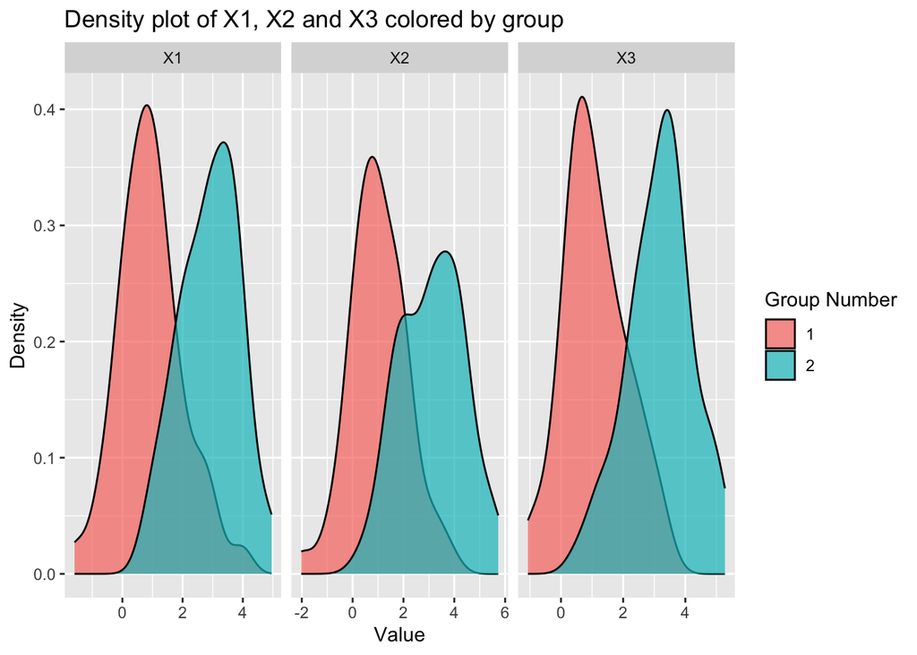

```r
## load the required libraries
library(corrplot)

## create density plots
data %>%
    select(group, X1, X2, X3) %>%
    pivot_longer(-group, names_to = "variables", values_to = "value") %>%
    ggplot(aes(x = value, fill = as.factor(group))) + geom_density(alpha = 0.7) +
    facet_wrap(~variables, scales = "free_x") + labs(x = "Value",
    y = "Density", fill = "Group Number", title = "Density plot of X1, X2 and X3 colored by group")
```

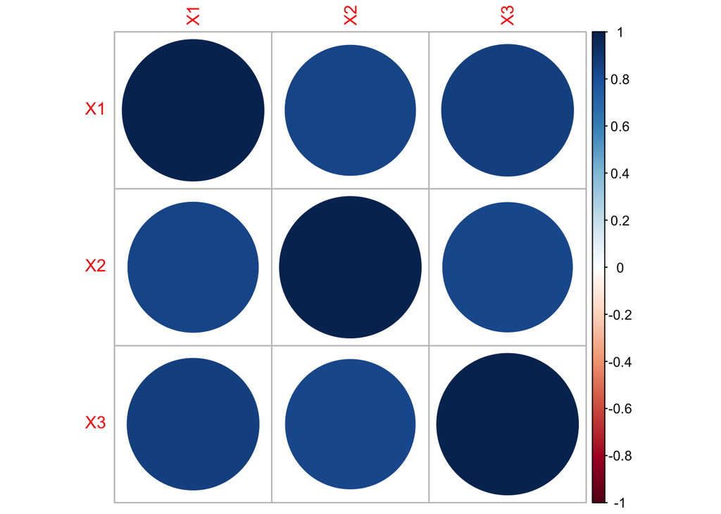

```r
## calculate the correlated matrix
cor_matrix <- cor(data[, 2:4])

## plot the correlation of the data
corrplot(cor_matrix, method = "circle")
```

### 3.Perform PCA on the Data

- Perform PCA on the data.
- Make a plot of the cumulative variance explained by the PCs.
- Make bivariate plots of all combinations of the scores on the first, second, and third PC colored by group membership.

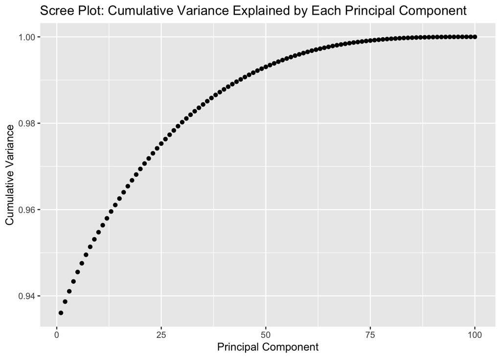

```r
## perform the pca on data and scale within prcomp
pca_data <- prcomp(data[-1], center = FALSE, scale. = TRUE)

## proportion of variance explained by each PC
pca_sum <- summary(pca_data)

## calculate cumulative variance
cum_var <- tibble(PC = 1:100, cum_var = summary(pca_data)$importance[3,
    ])


## plot the cumulative proportion of the variation
## explained by each PC
ggplot(cum_var, aes(x = PC, y = cum_var)) + geom_point() + labs(title = "Scree Plot: Cumulative Variance Explained by Each Principal Component",
    y = "Cumulative Variance", x = "Principal Component")
```

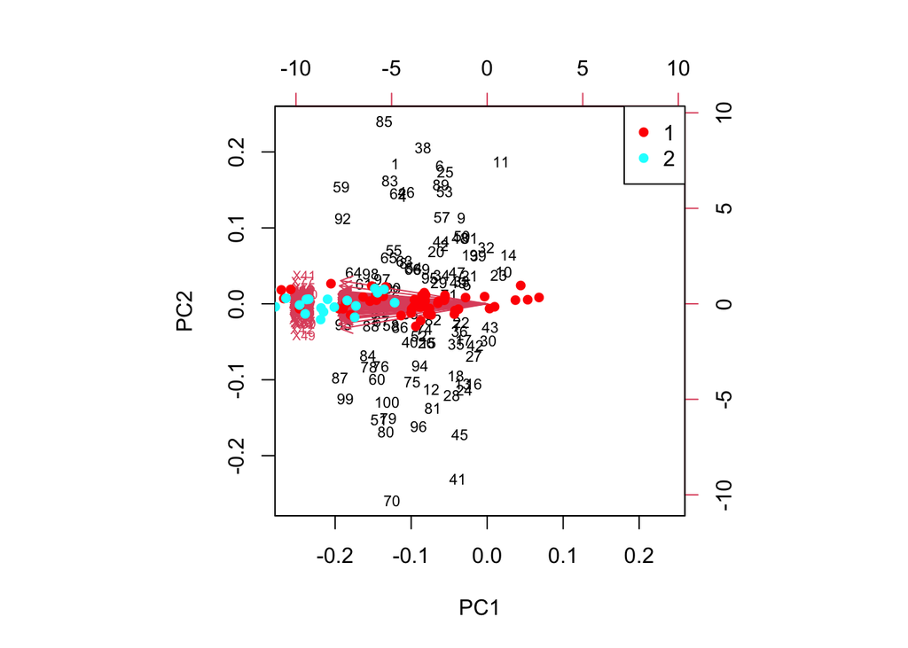

```r
## create the bivariate plot
biplot(pca_data, choices = 1:2, cex = c(0.7, 0.6))
groups <- as.factor(data$group)
colors <- rainbow(length(levels(groups)))

## add points to each group
for (i in seq_along(levels(groups))) {
    group_points <- pca_data$x[groups == levels(groups)[i], 1:2]
    points(group_points, col = colors[i], pch = 16)
}

## add the legend
legend("topright", legend = levels(groups), col = colors, pch = 16)
```

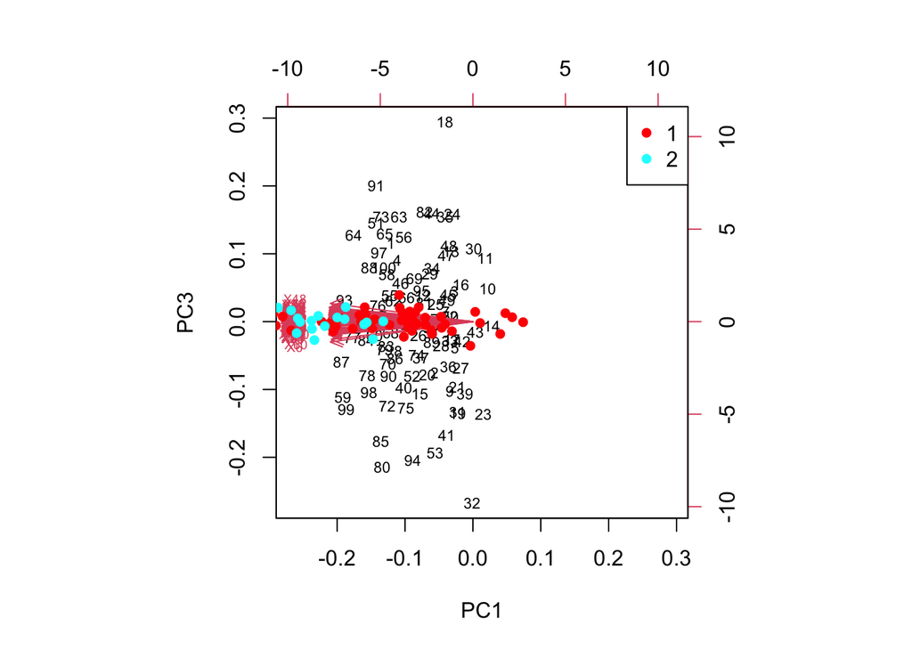

```r
## add another bivariate plot (PC1 vs PC3)
biplot(pca_data, choices = c(1, 3), cex = c(0.7, 0.6))
for (i in seq_along(levels(groups))) {
    group_points <- pca_data$x[groups == levels(groups)[i], c(1,
        3)]
    points(group_points, col = colors[i], pch = 16)
}
legend("topright", legend = levels(groups), col = colors, pch = 16)
```

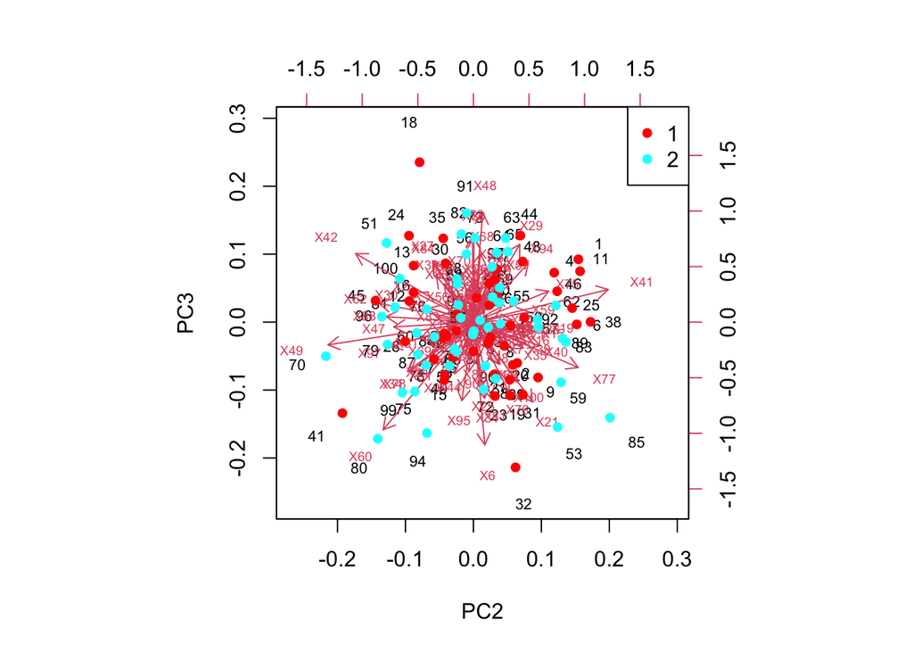

```r
## add last bivariate plot (PC2 vs PC3)
biplot(pca_data, choices = c(2, 3), cex = c(0.7, 0.6))
for (i in seq_along(levels(groups))) {
    group_points <- pca_data$x[groups == levels(groups)[i], c(2,
        3)]
    points(group_points, col = colors[i], pch = 16)
}
legend("topright", legend = levels(groups), col = colors, pch = 16)
```